# Long-read RNA-seq analysis with bambu across bulk, single-cell and spatial data

This tutorial uses bambu, a Bioconductor package, to perform novel transcript discovery and quantification on the bulk and single-cell samples of the [SG-NEx project](https://github.com/GoekeLab/sg-nex-data). To illustrate downstream analysis (for example, differential transcript usage and isoform switching) using bambu’s output, we use IsoformSwitchAnalyzeR.

## **Content**

- Download data for the tutorial
- Part 1: Transcript discovery and quantification with bambu
  - Aligning the reads to the genome
  - Running bambu
  - Interpreting the extended annotation
  - Interpreting bambu’s count type
  - Extending bambu to single-cell and spatial data using bambu-pipe
    - Cell type clustering on the single-cell mixture data
- Part 2: Differential transcript usage using bambu’s output
  - Identifying candidate genes with DTU events
  - Visualising isoform switching event
- Reference

## **Download data for the tutorial**

We load the packages that we use in this tutorial.

```r
library(bambu)
library(IsoformSwitchAnalyzeR)
library(Seurat)
library(Gviz)

library(ggplot2)
library(dplyr)
```

The code below creates the project folder of the tutorial, `bambu_tutorial`, in the same directory of this `.Rmd` file, and makes it the working directory of all later code chunks. All later code reads and writes files in this folder.

```r
knitr::opts_chunk$set(warning = FALSE, fig.align = "center")
project_dir <- "bambu_tutorial"
dir.create(project_dir, recursive = TRUE, showWarnings = FALSE)
knitr::opts_knit$set(root.dir = normalizePath(project_dir))
```

The following code provides the location of the data used for this tutorial from the SG-NEx S3 bucket downloadable with the [AWS CLI](https://aws.amazon.com/cli/). Replace `<project_dir>` with the full path of the folder `bambu_tutorial`. On Windows, run these commands in WSL or Git Bash.

```bash
# bulk data
# cd <project_dir>
# mkdir -p bulk
# aws s3 cp --no-sign-request s3://sg-nex-data/data/data_tutorial/annotations/hg38_chr22.fa ./bulk/
# aws s3 cp --no-sign-request s3://sg-nex-data/data/data_tutorial/annotations/hg38_chr22.fa.fai ./bulk/
# aws s3 cp --no-sign-request s3://sg-nex-data/data/data_tutorial/annotations/hg38_chr22.gtf ./bulk/
# aws s3 cp --no-sign-request s3://sg-nex-data/data/data_tutorial/fastq/HepG2_directRNA_sample1.fastq.gz ./bulk/
# aws s3 sync --no-sign-request s3://sg-nex-data/data/data_tutorial/bam ./bulk --exclude "*" --include "*_directRNA_sample*"
```

```bash
# single-cell data
# cd <project_dir>
# aws s3 sync --no-sign-request s3://sg-nex-data/data/data_tutorial/singlecell ./single_cell --exclude "*" \
#   --include "GIS_cellMix_HCT116-A549-HepG2-MCF7_joint/seurat_obj.rds" \
#   --include "GIS_cellMix_HCT116-A549-HepG2-MCF7_joint/extended_annotations.gtf" \
#   --include "GIS_cellMix_HCT116-A549-HepG2-MCF7_joint/transcript_counts_clusters/se_transcript_counts_clusters.rds" \
#   --include "GIS_cellMix_HCT116-A549-HepG2-MCF7_joint/unique_counts/se_unique_counts.rds" \
#   --include "isoformSwitchList.rds" --include "*_ENSG00000183891.bam*"
```

## **Part 1: Transcript discovery and quantification with bambu**

To run bambu, we need reads aligned to the genome (BAM files), a reference annotation (GTF file, TxDb object or bambu annotation object) and a reference genome sequence (FASTA file or BSgenome). In this tutorial, we use the A549 and HepG2 SG-NEx direct RNA samples from the bulk RNA-seq experiment.

### **Aligning the reads to the genome**

Genome alignment is done using minimap2, followed by sorting and indexing of the alignments using samtools. For this tutorial, the aligned BAM files are already available in the download. The bash command for running minimap2 and samtools is shown below.

```bash
cd <project_dir>/bulk
minimap2 -ax splice -uf -k14 -t 2 hg38_chr22.fa HepG2_directRNA_sample1.fastq.gz 2> minimap2.log \
  | samtools sort -@ 2 -o HepG2_directRNA_sample1.bam
samtools index HepG2_directRNA_sample1.bam
ls *.bam
```

```
A549_directRNA_sample1.bam  A549_directRNA_sample3.bam   HepG2_directRNA_sample2.bam
A549_directRNA_sample2.bam  HepG2_directRNA_sample1.bam  HepG2_directRNA_sample3.bam
```

For further information on using minimap2 and samtools under different settings, refer to the minimap2 and samtools documentation.

### **Running bambu**

First, we define the genome and annotation files and list the BAM files of the 6 samples. Here, `prepareAnnotations()` makes the bambu annotation object from the GTF file. In practice, the bambu annotation can be reused in different bambu runs to save processing time.

```r
fa_file <- "bulk/hg38_chr22.fa"
gtf_file <- "bulk/hg38_chr22.gtf"
annotations <- prepareAnnotations(gtf_file)
bam_files <- list.files("bulk", pattern = "\\.bam$", full.names = TRUE)
bam_files
```

```
## [1] "bulk/A549_directRNA_sample1.bam"  "bulk/A549_directRNA_sample2.bam"
## [3] "bulk/A549_directRNA_sample3.bam"  "bulk/HepG2_directRNA_sample1.bam"
## [5] "bulk/HepG2_directRNA_sample2.bam" "bulk/HepG2_directRNA_sample3.bam"
```

Next, we run bambu to perform transcript discovery and quantification. The output `se` is a `SummarizedExperiment` with one row for each transcript (annotated and novel) and one column for each sample. `rcOutDir` saves the read classes (the reads grouped by their splice junctions) as `.rds` files. Later bambu runs can start from these files and skip the BAM processing, as in the NDR part below.

```r
dir.create("bulk/rc", showWarnings = FALSE)
# rcOutDir: folder for the read classes
# ncore: number of CPUs
se <- bambu(reads = bam_files, annotations = annotations, genome = fa_file,
            rcOutDir = "bulk/rc", ncore = 1)
```

```
## --- Start generating read class files ---
```

[output not shown]

[output not shown]

[output not shown]

[output not shown]

[output not shown]

[output not shown]

[output not shown]

```
## Detected 15 warnings across the samples during read class construction. Access warnings with metadata(bambuOutput)$warnings
```

```
## --- Start extending annotations ---
```

```
## Using a novel discovery rate (NDR) of: 0.129
```

```
## --- Start isoform quantification ---
```

```
## --- Finished running Bambu ---
```

```r
se
```

```
## class: RangedSummarizedExperiment
## dim: 4547 6
## metadata(2): incompatibleCounts warnings
## assays(4): counts CPM fullLengthCounts uniqueCounts
## rownames(4547): BambuTx1 BambuTx2 ... ENST00000641967 ENST00000642075
## rowData names(11): TXNAME GENEID ... txid eqClassById
## colnames(6): A549_directRNA_sample1 A549_directRNA_sample2 ...
##   HepG2_directRNA_sample2 HepG2_directRNA_sample3
## colData names(1): name
```

The figure shows the structure of a `SummarizedExperiment`. `assays` holds the count matrices (rows are transcripts, columns are samples). `rowRanges` and `rowData` hold the transcript information, and `colData` holds the sample information.

[figure not shown]

Structure of a `SummarizedExperiment`. Figure from the [SummarizedExperiment vignette](https://www.bioconductor.org/packages/devel/bioc/vignettes/SummarizedExperiment/inst/doc/SummarizedExperiment.html).

### **Interpreting the extended annotation**

`rowRanges(se)` is the extended annotation: the reference annotation together with the novel transcripts. It is a `GRangesList` with one `GRanges` for each transcript, which holds the exons of the transcript. We pick 1 novel transcript as an example, in the gene ENSG00000100097, and look at its exons.

```r
bulk_gene <- "ENSG00000100097"
bulk_novel_tx <- rownames(se)[rowData(se)$GENEID == bulk_gene & rowData(se)$novelTranscript]
rowRanges(se)[bulk_novel_tx]
```

[output not shown]

`rowData(se)` gives information about each transcript:

- `TXNAME`, `GENEID`: transcript and gene ID. Novel transcripts have the IDs `BambuTx...`, and novel genes have the IDs `BambuGene...`.
- `novelTranscript`, `novelGene`: `TRUE` for a novel transcript or gene.
- `NDR`: the novel discovery rate (NDR) score of the transcript. A low score means a high-confidence transcript.

We show these columns for the transcripts of the example gene.

```r
rowData(se)[rowData(se)$GENEID == bulk_gene, c("TXNAME", "GENEID", "novelTranscript", "novelGene", "NDR")]
```

```
## DataFrame with 8 rows and 5 columns
##                          TXNAME          GENEID novelTranscript novelGene
##                     <character>     <character>       <logical> <logical>
## BambuTx11             BambuTx11 ENSG00000100097            TRUE     FALSE
## ENST00000215909 ENST00000215909 ENSG00000100097           FALSE     FALSE
## ENST00000425542 ENST00000425542 ENSG00000100097           FALSE     FALSE
## ENST00000454173 ENST00000454173 ENSG00000100097           FALSE     FALSE
## ENST00000464120 ENST00000464120 ENSG00000100097           FALSE     FALSE
## ENST00000472321 ENST00000472321 ENSG00000100097           FALSE     FALSE
## ENST00000480207 ENST00000480207 ENSG00000100097           FALSE     FALSE
## ENST00000489315 ENST00000489315 ENSG00000100097           FALSE     FALSE
##                       NDR
##                 <numeric>
## BambuTx11        0.105727
## ENST00000215909  0.000000
## ENST00000425542        NA
## ENST00000454173        NA
## ENST00000464120        NA
## ENST00000472321        NA
## ENST00000480207        NA
## ENST00000489315        NA
```

`plotBambu()` plots the exons of all transcripts of this gene, together with the count expression of each transcript in each sample that will be explained later in more detail.

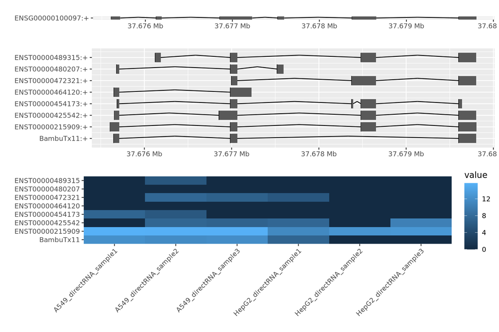

```r
invisible(plotBambu(se, type = "annotation", gene_id = bulk_gene))
```

**Modulating the sensitivity of transcript discovery**

bambu gives each candidate transcript a score. The NDR threshold is approximately the fraction of novel transcripts among all transcripts that pass the threshold: NDR = 0.1 means that approximately 10% of the output transcripts are novel. By default, bambu selects the NDR from the predicted completeness of the reference annotation. A low NDR gives fewer novel transcripts with a higher precision, and a high NDR gives more novel transcripts with a higher sensitivity. Here we start from the saved read classes in `bulk/rc/` and run only transcript discovery (`quant = FALSE`) with 2 other NDR values. The table gives the number of novel transcripts for each NDR, together with the recommended NDR of the first run.

```r
rc_files <- list.files("bulk/rc", pattern = "\\.rds$", full.names = TRUE)
ndr_table <- data.frame(NDR = metadata(rowRanges(se))$NDRthreshold,
                        novel_transcripts = sum(rowData(se)$novelTranscript))
for (ndr in c(0.05, 0.3)) {
  annotation_ndr <- bambu(reads = rc_files, annotations = annotations, genome = fa_file,
                          NDR = ndr, quant = FALSE, ncore = 1)
  ndr_table <- rbind(ndr_table, data.frame(NDR = ndr,
                                           novel_transcripts = sum(mcols(annotation_ndr)$novelTranscript)))
}
```

```
## Detected 15 warnings across the samples during read class construction. Access warnings with metadata(bambuOutput)$warnings
```

```
## --- Start extending annotations ---
```

```
## Detected 15 warnings across the samples during read class construction. Access warnings with metadata(bambuOutput)$warnings
```

```
## --- Start extending annotations ---
```

[output not shown]

```r
ndr_table <- ndr_table[order(ndr_table$NDR), ]
rownames(ndr_table) <- NULL
ndr_table
```

```
##     NDR novel_transcripts
## 1 0.050                21
## 2 0.129                60
## 3 0.300               147
```

### **Interpreting bambu’s count type**

The `SummarizedExperiment` stores different count types together with the sample information with `assays(se)` and `colData(se)`. For bulk data, `assays(se)` provides 4 different types of transcript count matrices:

- `counts`: the estimate of the reads of each transcript from the expectation-maximisation (EM) algorithm. It uses all reads: full-length reads, partial reads and reads that are compatible with more than 1 transcript.
- `CPM`: `counts` normalised to counts per million.
- `fullLengthCounts`: the reads that cover the full transcript (all its splice junctions), from the EM.
- `uniqueCounts`: the reads that are compatible with only this transcript.

```r
colData(se)
```

```
## DataFrame with 6 rows and 1 column
##                                           name
##                                    <character>
## A549_directRNA_sample1  A549_directRNA_sample1
## A549_directRNA_sample2  A549_directRNA_sample2
## A549_directRNA_sample3  A549_directRNA_sample3
## HepG2_directRNA_sample1 HepG2_directRNA_samp..
## HepG2_directRNA_sample2 HepG2_directRNA_samp..
## HepG2_directRNA_sample3 HepG2_directRNA_samp..
```

```r
assayNames(se)
```

```
## [1] "counts"           "CPM"              "fullLengthCounts" "uniqueCounts"
```

```r
head(assays(se)$counts)
```

```
##          A549_directRNA_sample1 A549_directRNA_sample2 A549_directRNA_sample3
## BambuTx1                2.00000                0.00000                0.00000
## BambuTx2                2.00000               30.78720               11.40476
## BambuTx3                4.64865               37.47735               24.52325
## BambuTx4                2.27273                3.22869                1.08501
## BambuTx5                2.40125               26.70502                4.88876
## BambuTx6                2.00000               34.60005                9.87247
##          HepG2_directRNA_sample1 HepG2_directRNA_sample2
## BambuTx1                 1.00000                 0.00000
## BambuTx2                13.00000                 0.00000
## BambuTx3                11.80000                 2.57143
## BambuTx4                 0.00000                 0.00000
## BambuTx5                11.73898                 0.00000
## BambuTx6                 4.00000                 0.00000
##          HepG2_directRNA_sample3
## BambuTx1                       0
## BambuTx2                       0
## BambuTx3                       0
## BambuTx4                       0
## BambuTx5                       0
## BambuTx6                       1
```

```r
head(assays(se)$fullLengthCounts)
```

```
##          A549_directRNA_sample1 A549_directRNA_sample2 A549_directRNA_sample3
## BambuTx1                      2                      0                      0
## BambuTx2                      1                      7                      1
## BambuTx3                      3                     26                     18
## BambuTx4                      2                      3                      1
## BambuTx5                      1                     18                      3
## BambuTx6                      2                     18                      4
##          HepG2_directRNA_sample1 HepG2_directRNA_sample2
## BambuTx1                       1                       0
## BambuTx2                       2                       0
## BambuTx3                       7                       2
## BambuTx4                       0                       0
## BambuTx5                       6                       0
## BambuTx6                       0                       0
##          HepG2_directRNA_sample3
## BambuTx1                       0
## BambuTx2                       0
## BambuTx3                       0
## BambuTx4                       0
## BambuTx5                       0
## BambuTx6                       1
```

We can also obtain gene counts by applying `transcriptToGeneExpression()` on the transcript `se` object.

```r
se_gene <- transcriptToGeneExpression(se)
se_gene
```

```
## class: RangedSummarizedExperiment
## dim: 1346 6
## metadata(0):
## assays(2): counts CPM
## rownames(1346): BambuGene1 BambuGene3 ... ENSG00000284654
##   ENSG00000284665
## rowData names(2): GENEID newGeneClass
## colnames(6): A549_directRNA_sample1 A549_directRNA_sample2 ...
##   HepG2_directRNA_sample2 HepG2_directRNA_sample3
## colData names(1): name
```

Finally, we can also use `writeBambuOutput()` to write the extended annotation and the counts to GTF and text files for downstream analysis on non-R platforms.

```r
writeBambuOutput(se, path = "bulk/output")
list.files("bulk/output")
```

```
## [1] "CPM_transcript.txt"              "counts_gene.txt"
## [3] "counts_transcript.txt"           "extended_annotations.gtf"
## [5] "fullLengthCounts_transcript.txt" "uniqueCounts_transcript.txt"
```

| Output file | Description |
| --- | --- |
| extended_annotations.gtf | Extended annotation: reference and novel transcripts and genes. **It can be opened together with the BAM files in a genome browser, for example [IGV](https://igv.org/).** |
| counts_transcript.txt | `counts` of each transcript in each sample. |
| CPM_transcript.txt | `CPM` of each transcript in each sample. |
| fullLengthCounts_transcript.txt | `fullLengthCounts` of each transcript in each sample. |
| uniqueCounts_transcript.txt | `uniqueCounts` of each transcript in each sample. |
| counts_gene.txt | Gene counts of each gene in each sample. |

### **Extending bambu to single-cell and spatial data using bambu-pipe**

bambu-pipe is a Nextflow pipeline that runs bambu on long-read single-cell and spatial data. It performs context-aware transcript discovery and quantification in 3 stages:

- **Preprocessing**: (optional) quality score filtering with Chopper, barcode and UMI identification and demultiplexing with Flexiplex, and primer removal with Cutadapt.
- **Alignment**: genome alignment with minimap2.
- **Transcript discovery and quantification**: read class construction and transcript discovery with bambu, jointly across all samples; then (optional) transcript quantification with bambu’s clustered EM or single-cell EM. **In clustered EM, we use Seurat to cluster the cells by their gene expression across all samples, and bambu quantifies the transcripts of each cluster in each sample.** In single-cell EM, bambu quantifies the transcripts of each cell, or of each spot in spatial samples.

The rest of this tutorial uses real single-cell data: 3 libraries of the same HCT116-A549-HepG2-MCF7 cell-line mixture, sequenced with different 10x chemistry and sequencing technology.

| Sample | Cell lines | 10x chemistry | Technology |
| --- | --- | --- | --- |
| HCT116ONT3p | HCT116, A549, HepG2, MCF7 | 10x 3’ v3 | ONT |
| HCT116ONT5p | HCT116, A549, HepG2, MCF7 | 10x 5’ v2 | ONT |
| HCT116PB5p | HCT116, A549, HepG2, MCF7 | 10x 5’ v2 | PacBio |

The pipeline runs all stages from the FASTQ files to the transcript counts in 1 command, with transcript discovery jointly across the 3 samples. `--quantification_mode clusteredEM` runs the clustered EM, and `--seurat_resolution` sets the resolution of the Seurat clustering.

```bash
nextflow run GoekeLab/bambu-pipe -r v0.10.3 -profile singularity,hpc \
  --input samplesheet.csv \
  --genome GRCh38.primary_assembly.genome.fa \
  --annotation gencode.v49.primary_assembly.annotation.gtf \
  --quantification_mode clusteredEM \
  --seurat_resolution 0.01 \
  --output_dir bambupipe_output
```

where `samplesheet.csv` has one row for each sample with columns: sample name (`sample`), path to the FASTQ or BAM file (`path`), 10x library chemistry (`chemistry`) and sequencing technology (`technology`, `ONT` or `PacBio`).

```
# samplesheet.csv
sample,path,chemistry,technology
HCT116ONT3p,GIS_cellMix_HCT116-A549-HepG2-MCF7_3primeSingleCellcDNA_Rep1_Run1.fastq.gz,10x3v3,ONT
HCT116ONT5p,GIS_cellMix_HCT116-A549-HepG2-MCF7_5primeSingleCellcDNA_Rep1_Run2Run3combined.fastq.gz,10x5v2,ONT
HCT116PB5p,GIS_cellMix_HCT116-A549-HepG2-MCF7_5primeSingleCellcDNAPacBio_Rep1_Run1.fastq.gz,10x5v2,PacBio
```

The output of this joint sample run is deposited in the data tutorial folder of the SG-NEx S3 bucket, and is already downloaded under `bambu_tutorial/single_cell/GIS_cellMix_HCT116-A549-HepG2-MCF7_joint`. For the rest of the tutorial, we use some of these output files. For a complete description of the output files and different configurations to run bambu-pipe, see the [bambu-pipe README](https://github.com/GoekeLab/bambu-pipe/tree/v0.10.3#output).

#### **Cell type clustering on the single-cell mixture data**

bambu-pipe gives a Seurat object with the cells of the 3 libraries, the PCA, the Harmony embedding (corrected for the sequencing technology and the chemistry) and the clusters. We read the Seurat object and the transcript counts of each cluster in each library.

```r
joint_dir <- "single_cell/GIS_cellMix_HCT116-A549-HepG2-MCF7_joint"
seu <- readRDS(file.path(joint_dir, "seurat_obj.rds"))
se_tx <- readRDS(file.path(joint_dir, "transcript_counts_clusters/se_transcript_counts_clusters.rds"))
seu
```

```
## An object of class Seurat
## 52023 features across 26595 samples within 1 assay
## Active assay: RNA (52023 features, 2000 variable features)
##  7 layers present: counts.HCT116ONT5p, counts.HCT116ONT3p, counts.HCT116PB5p, data.HCT116ONT5p, data.HCT116ONT3p, data.HCT116PB5p, scale.data
##  2 dimensional reductions calculated: pca, harmony
```

We calculate the UMAP on the Harmony embedding with the 30 dimensions that bambu-pipe uses for the clustering. We give each bambu-pipe cluster the name of its cell line, and show the cell lines on the UMAP. The cell line label for each cluster is annotated by the correlation of the cluster expression with the SG-NEx bulk expression of the cell lines.

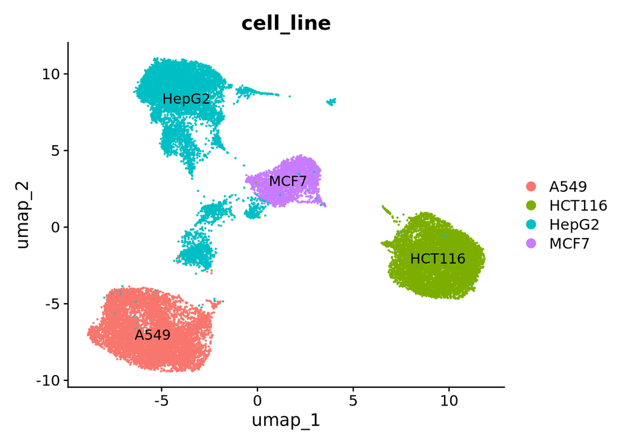

```r
seu <- RunUMAP(seu, reduction = "harmony", dims = 1:30, verbose = FALSE)
cluster_cell_line <- c("0" = "HepG2", "1" = "A549", "2" = "HCT116", "3" = "MCF7")
seu$cell_line <- unname(cluster_cell_line[as.character(seu$harmony_clusters)])
DimPlot(seu, reduction = "umap", group.by = "cell_line", label = TRUE)
```

**Notes**

- A cluster is not only a cell type. For spatial data, a cluster can also be a region of spots, and bambu-pipe also runs on spatial Visium and Visium HD data.
- You can also provide your own cell-to-cluster assignments, using the `--manual_clustering true` option and a CSV file with the columns `id` (a barcode of the cell or spot) and `cluster`.

For a complete description of the manual clustering option or other advanced features of bambu-pipe, refer to the [bambu-pipe README](https://github.com/GoekeLab/bambu-pipe/tree/v0.10.3#advanced-usage).

## **Part 2: Differential transcript usage using bambu’s output**

We now have bambu’s output from the joint single-cell run on real data. Next, we use it to find isoform switching events between 2 cell lines of the mixture. Differential transcript usage (DTU) is a change in the fraction of a gene’s expression that comes from each of its transcripts (the isoform fraction, IF) between conditions. An isoform switch is a type of DTU in which the IF of one isoform increases and the IF of another isoform of the same gene decreases. In this section, we use IsoformSwitchAnalyzeR to find the isoform switches in bambu’s output, and we show 1 gene with a switch between a novel and an annotated transcript with Seurat and Gviz.

### **Identifying candidate genes with DTU events**

In this tutorial, we select the A549 and HCT116 cell line clusters from different chemistry and/or technology to perform DTU based on the counts from clustered EM output.

```r
compared_cell_lines <- c("A549", "HCT116")
se_tx$cell_line <- unname(cluster_cell_line[sub("cluster_", "", se_tx$cluster)])
se_pair <- se_tx[, se_tx$cell_line %in% compared_cell_lines]
se_pair
```

```
## class: RangedSummarizedExperiment
## dim: 509819 6
## metadata(2): incompatibleCounts seType
## assays(4): counts CPM fullLengthCounts uniqueCounts
## rownames(509819): BambuTx4323 BambuTx7430 ... ENST00000973046.1
##   ENST00000973047.1
## rowData names(13): TXNAME GENEID ... maxTxScore maxTxScore.noFit
## colnames(6): HCT116ONT5p_cluster_1 HCT116ONT5p_cluster_2 ...
##   HCT116PB5p_cluster_1 HCT116PB5p_cluster_2
## colData names(5): id sampleName cluster barcodes cell_line
```

We ran `IsoformSwitchAnalyzeR` in 2 steps:

1. We write the design table. Each column of `se_pair` (1 cluster in 1 library) is a pseudobulk replicate of its cell line. The condition is the cell line, and the columns `technology` and `chemistry` correct for the batch effects of the 3 libraries: IsoformSwitchAnalyzeR adds them to the DEXSeq model as covariates.
2. IsoformSwitchAnalyzeR imports the counts and the bambu extended annotation (`importRdata()`), filters the isoforms (`preFilter()`) and tests each gene for a change in the IF of its isoforms between the 2 cell lines (`isoformSwitchTestDEXSeq()`). The output has the change of IF (`dIF`) and the q-value of each isoform.

The 2 steps take a long time, so their code is commented out, and we load the precomputed result from the download.

```r
# step 1: design table
# design <- data.frame(
#   sampleID = colnames(se_pair),
#   condition = se_pair$cell_line,
#   technology = ifelse(grepl("ONT", se_pair$sampleName), "ONT", "PacBio"),
#   chemistry = ifelse(grepl("3p", se_pair$sampleName), "10x3v3", "10x5v2"))

# step 2: isoform switch test
# keep the transcripts with 100 or more counts, summed over the A549 and HCT116 clusters
# keep_tx <- rowSums(assay(se_pair, "counts")) >= 100
# keep the genes with 2 or more of these transcripts
# gene_ids <- rowData(se_pair)$GENEID
# se_pair_filtered <- se_pair[keep_tx & gene_ids %in% names(which(table(gene_ids[keep_tx]) >= 2)), ]
# to_df <- function(m) data.frame(isoform_id = rownames(m), as.matrix(m), check.names = FALSE)
# switch_list <- importRdata(
#   isoformCountMatrix = to_df(assay(se_pair_filtered, "counts")),
#   isoformRepExpression = to_df(assay(se_pair_filtered, "CPM")),
#   designMatrix = design,
#   isoformExonAnnoation = file.path(joint_dir, "extended_annotations.gtf"),
#   addAnnotatedORFs = FALSE, detectUnwantedEffects = FALSE, fixStringTieAnnotationProblem = FALSE,
#   ignoreSurplusIsoforms = TRUE, estimateDifferentialGeneRange = FALSE)
# keep the isoforms with 30 or more counts in 70% or more of the samples of each cell line,
# and with an IF of 0.1 or more in 50% or more of these samples; remove the genes with 1 isoform
# switch_list <- preFilter(switch_list, isoCount = 30, min.Count.prop = 0.7, IFcutoff = 0.1)
# switch_list <- isoformSwitchTestDEXSeq(switch_list, alpha = 0.05, dIFcutoff = 0.1,
#   reduceToSwitchingGenes = FALSE, reduceFurtherToGenesWithConsequencePotential = FALSE)
switch_list <- readRDS("single_cell/isoformSwitchList.rds")
extractSwitchSummary(switch_list, alpha = 0.05, dIFcutoff = 0.1)
```

```
##       Comparison nrIsoforms nrSwitches nrGenes
## 1 A549 vs HCT116       1236        517     754
```

Here you can see there are 754 genes with isoform switching events.

In this tutorial, we select a candidate gene with a high-confidence isoform switching event with a novel transcript, based on the following criteria:

1. The isoform has q < 0.05 and abs(dIF) > 0.1.
2. The isoform has full-length counts and unique counts in the cell line with its higher IF.

The volcano plot shows the dIF of each isoform against its -log10 q. Points with -log10 q above 30 are drawn at the top edge. The blue points pass criterion 1, and the red points pass criteria 1 and 2. The black points are the 2 isoforms of the selected gene.

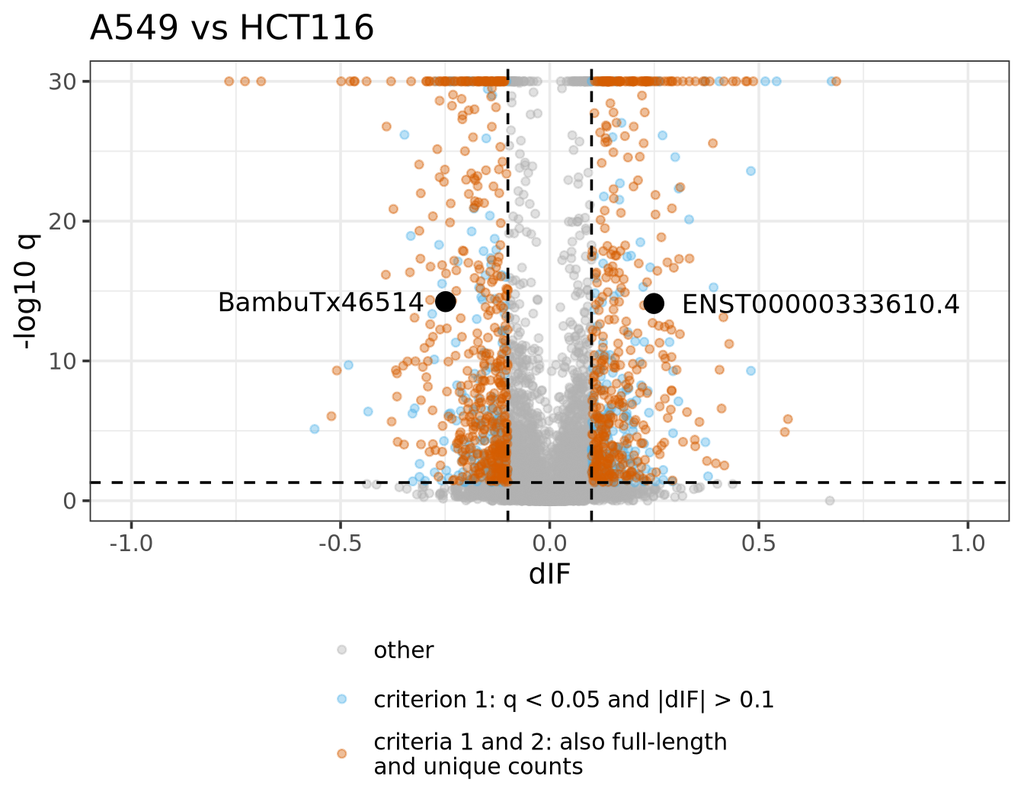

```r
isoform_features <- switch_list$isoformFeatures
condition_1 <- isoform_features$condition_1[1]
condition_2 <- isoform_features$condition_2[1]
# sum of 1 assay over the clusters of each cell line: 1 row for each isoform, 1 column for each cell line
sum_by_cell_line <- function(assay_name) {
  counts <- as.matrix(assay(se_pair, assay_name)[isoform_features$isoform_id, ])
  sapply(c(condition_1, condition_2), function(cl) rowSums(counts[, se_pair$cell_line == cl, drop = FALSE]))
}
full_length_sum <- sum_by_cell_line("fullLengthCounts")
unique_sum <- sum_by_cell_line("uniqueCounts")
# column of the cell line with the higher IF of each isoform (dIF = IF2 - IF1)
higher_if <- cbind(seq_len(nrow(isoform_features)), ifelse(isoform_features$dIF > 0, 2, 1))
volcano <- isoform_features %>%
  mutate(criterion_1 = isoform_switch_q_value < 0.05 & abs(dIF) > 0.1,
         criterion_2 = full_length_sum[higher_if] > 0 & unique_sum[higher_if] > 0,
         criteria = case_when(criterion_1 & criterion_2 ~ "criteria 1 and 2",
                              criterion_1 ~ "criterion 1 only",
                              TRUE ~ "other"),
         criteria = factor(criteria, levels = c("other", "criterion 1 only", "criteria 1 and 2")),
         log_q = pmin(-log10(isoform_switch_q_value), 30)) %>%
  arrange(criteria)
example_tx <- c("BambuTx46514", "ENST00000333610.4")
example_gene <- unique(isoform_features$gene_id[isoform_features$isoform_id %in% example_tx])
example_points <- filter(volcano, isoform_id %in% example_tx)
ggplot(volcano, aes(dIF, log_q, colour = criteria)) +
  geom_point(size = 1.5, alpha = 0.4) +
  geom_point(data = example_points, colour = "black", size = 4) +
  # label on the left of the point for dIF < 0, on the right for dIF > 0
  geom_text(data = example_points, aes(label = isoform_id, hjust = ifelse(dIF < 0, 1.1, -0.1)),
            colour = "black", size = 4.5) +
  scale_colour_manual(name = NULL,
                      values = c(`other` = "grey70", `criterion 1 only` = "#56B4E9",
                                 `criteria 1 and 2` = "#D55E00"),
                      labels = c(`other` = "other",
                                 `criterion 1 only` = "criterion 1: q < 0.05 and |dIF| > 0.1",
                                 `criteria 1 and 2` = "criteria 1 and 2: also full-length\nand unique counts")) +
  geom_vline(xintercept = c(-0.1, 0.1), linetype = "dashed") +
  geom_hline(yintercept = -log10(0.05), linetype = "dashed") +
  coord_cartesian(xlim = c(-1, 1), ylim = c(0, 30)) +
  labs(x = "dIF", y = "-log10 q", title = paste(condition_1, "vs", condition_2)) +
  theme_bw(base_size = 14) +
  theme(legend.position = "bottom") +
  guides(colour = guide_legend(ncol = 1))
```

Among the candidate genes that satisfy criteria 1 and 2, we selected ENSG00000183891 with isoform switching usage between BambuTx46514 and ENST00000333610.4 for further analysis. The IsoformSwitchAnalyzeR output and the bambu counts of the 2 isoforms in each cluster are:

```r
isoform_features %>%
  filter(isoform_id %in% example_tx) %>%
  select(isoform_id, condition_1, condition_2, IF1, IF2, dIF, isoform_switch_q_value)
```

```
##          isoform_id condition_1 condition_2    IF1    IF2    dIF
## 1      BambuTx46514        A549      HCT116 0.5819 0.3329 -0.249
## 2 ENST00000333610.4        A549      HCT116 0.4181 0.6671  0.249
##    isoform_switch_q_value
## 1 0.000000000000005752612
## 2 0.000000000000007808345
```

```r
as.matrix(assay(se_pair[example_tx, ], "counts"))
```

```
##                   HCT116ONT5p_cluster_1 HCT116ONT5p_cluster_2
## BambuTx46514                   232.1859              31.66244
## ENST00000333610.4              198.7832              80.33756
##                   HCT116ONT3p_cluster_1 HCT116ONT3p_cluster_2
## BambuTx46514                   444.3285              51.60241
## ENST00000333610.4              280.6715              97.39759
##                   HCT116PB5p_cluster_1 HCT116PB5p_cluster_2
## BambuTx46514                  530.7754             76.18182
## ENST00000333610.4             364.2246            128.27614
```

```r
as.matrix(assay(se_pair[example_tx, ], "fullLengthCounts"))
```

```
##                   HCT116ONT5p_cluster_1 HCT116ONT5p_cluster_2
## BambuTx46514                        224                    29
## ENST00000333610.4                   177                    65
##                   HCT116ONT3p_cluster_1 HCT116ONT3p_cluster_2
## BambuTx46514                        415                    47
## ENST00000333610.4                   212                    78
##                   HCT116PB5p_cluster_1 HCT116PB5p_cluster_2
## BambuTx46514                       482                   65
## ENST00000333610.4                  309                  103
```

```r
as.matrix(assay(se_pair[example_tx, ], "uniqueCounts"))
```

```
##                   HCT116ONT5p_cluster_1 HCT116ONT5p_cluster_2
## BambuTx46514                        225                    29
## ENST00000333610.4                   192                    74
##                   HCT116ONT3p_cluster_1 HCT116ONT3p_cluster_2
## BambuTx46514                        418                    48
## ENST00000333610.4                   262                    90
##                   HCT116PB5p_cluster_1 HCT116PB5p_cluster_2
## BambuTx46514                       486                   66
## ENST00000333610.4                  333                  109
```

### **Visualising isoform switching event**

The example gene is TTC32 (ENSG00000183891). In A549, the novel isoform BambuTx46514 is the most used isoform of the gene (IF 0.58). In HCT116, the annotated isoform ENST00000333610.4 is the most used isoform (IF 0.67). `switchPlotIsoExp()` shows the expression of each isoform of the gene in counts per million (CPM, the mean of the pseudobulk replicates), and `switchPlotIsoUsage()` shows its IF, in the 2 cell lines.

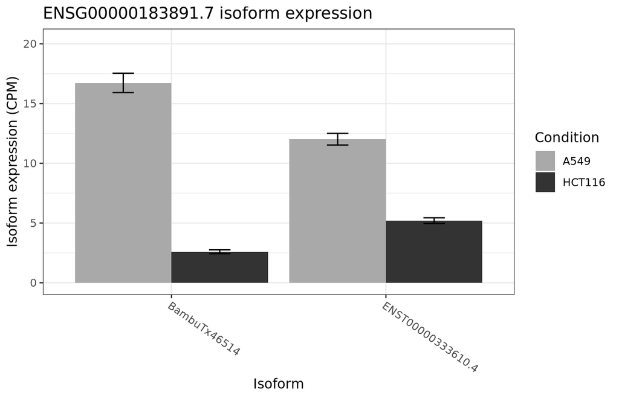

```r
print(switchPlotIsoExp(switch_list, gene = example_gene,
                       condition1 = condition_1, condition2 = condition_2) +
        labs(title = paste(example_gene, "isoform expression"), y = "Isoform expression (CPM)"))
```

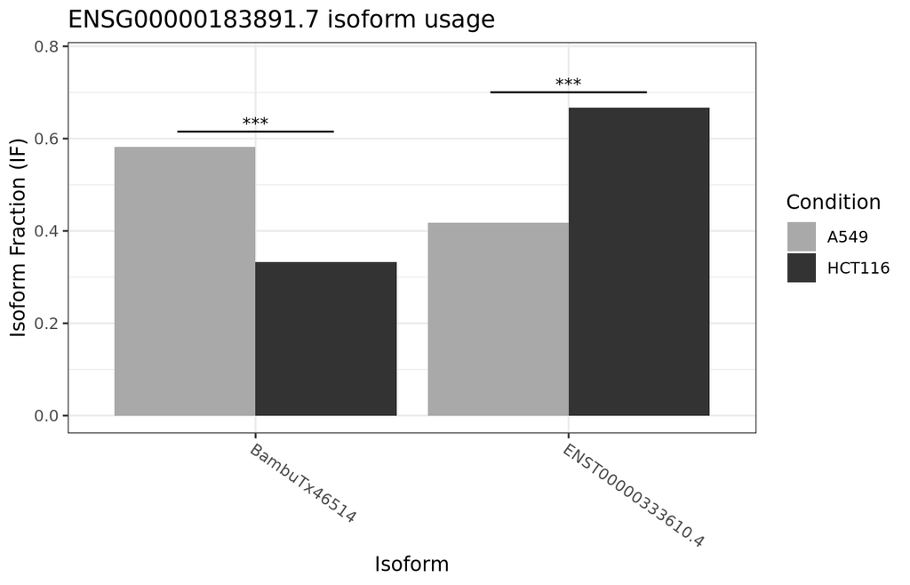

```r
print(switchPlotIsoUsage(switch_list, gene = example_gene,
                         condition1 = condition_1, condition2 = condition_2) +
        labs(title = paste(example_gene, "isoform usage")))
```

The isoform switching can also be visualised with UMAP using either unique counts or single-cell transcript counts (if bambu-pipe was run with single-cell EM). Here, we use the unique counts because we do not perform single-cell EM. Every cell has 0 to 3 unique counts of 1 isoform, so we add the unique counts of each cell and its 99 nearest neighbours in the Harmony space. The IF of an isoform is its count divided by the count of all isoforms of the gene. A cell is grey when the gene has fewer than 5 counts in its neighbourhood. Here, the novel isoform has the higher IF (red) in the A549 cells, and the annotated isoform has the higher IF in the HCT116 cells.

```r
seu_pair <- subset(seu, subset = cell_line %in% c(condition_1, condition_2))
se_unique <- readRDS(file.path(joint_dir, "unique_counts/se_unique_counts.rds"))
gene_isoforms <- rownames(se_unique)[rowData(se_unique)$GENEID == example_gene]
unique_counts <- as.matrix(assay(se_unique, "counts")[gene_isoforms, colnames(seu_pair)])
rm(se_unique)
# the 100 nearest cells of each cell (the cell and its 99 neighbours) in the Harmony space
seu_pair <- FindNeighbors(seu_pair, reduction = "harmony", dims = 1:30, k.param = 100,
                          return.neighbor = TRUE, graph.name = "harmony_nn", verbose = FALSE)
```

```
## Only one graph name supplied, storing nearest-neighbor graph only
```

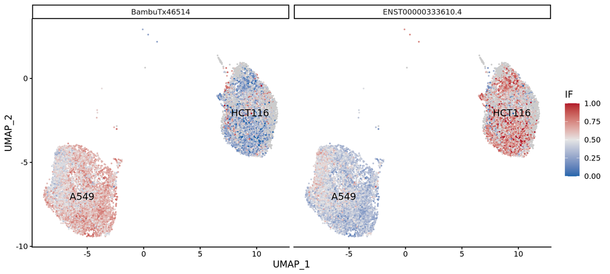

```r
neighbour_index <- Indices(seu_pair[["harmony_nn"]])
# unique counts of each isoform, summed over the 100 cells: 1 row for each cell, 1 column for each isoform
neighbourhood_counts <- apply(unique_counts, 1, function(counts)
  rowSums(matrix(counts[neighbour_index], nrow = nrow(neighbour_index))))
gene_counts <- rowSums(neighbourhood_counts)
# 1 row for each cell and isoform: UMAP position, cell line and IF
umap <- Embeddings(seu_pair, "umap")
if_data <- do.call(rbind, lapply(example_tx, function(tx) data.frame(
  UMAP_1 = umap[, 1], UMAP_2 = umap[, 2], cell_line = seu_pair$cell_line, isoform = tx,
  IF = ifelse(gene_counts >= 5, neighbourhood_counts[, tx] / gene_counts, NA))))
if_data$isoform <- factor(if_data$isoform, levels = example_tx)
label_position <- if_data %>%
  group_by(isoform, cell_line) %>%
  summarise(UMAP_1 = median(UMAP_1), UMAP_2 = median(UMAP_2), .groups = "drop")
ggplot(if_data, aes(UMAP_1, UMAP_2, colour = IF)) +
  geom_point(size = 0.3) +
  geom_text(data = label_position, aes(UMAP_1, UMAP_2, label = cell_line),
            inherit.aes = FALSE, size = 4) +
  scale_colour_gradient2(name = "IF", low = "#2166AC", mid = "grey90", high = "#B2182B",
                         midpoint = 0.5, limits = c(0, 1), na.value = "grey80") +
  facet_wrap(~ isoform) +
  theme_classic()
```

Finally, to validate full-length read support for this isoform switching event, we can visualise the read coverage and sashimi plot of the candidate gene using the Gviz package. To do that, we first split the cell mixture BAM file of the 5’ PacBio sample using the cell-to-cluster assignments in the Seurat object from the bambu-pipe output, and only keep the primary-aligned reads in the candidate gene region. The subsetted BAM files are already in the download, and we can load them using the Gviz package.

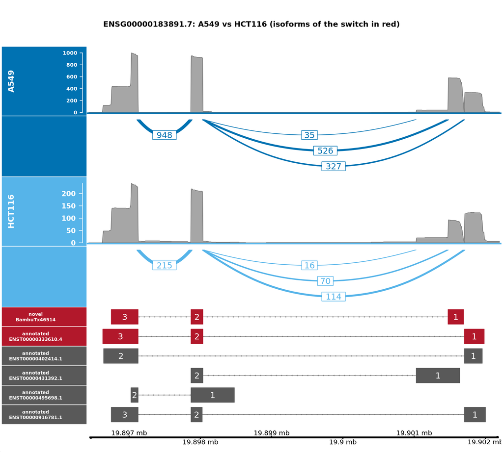

```r
# allow the contig names of the BAM header (for example GL000008.2)
options(ucscChromosomeNames = FALSE)
cell_line_colours <- setNames(c("#0072B2", "#56B4E9"), c(condition_1, condition_2))

# all isoforms of the gene in the bambu extended annotation, the 2 isoforms of the switch first
gene_isoforms <- rownames(se_tx)[rowData(se_tx)$GENEID == example_gene]
gene_isoforms <- c(example_tx, setdiff(gene_isoforms, example_tx))
gene_exons <- rowRanges(se_tx)[gene_isoforms]
is_novel_tx <- setNames(rowData(se_tx)$novelTranscript, rownames(se_tx))
gene_range <- range(unlist(gene_exons), ignore.strand = TRUE)
chrom <- as.character(seqnames(gene_range))

# 1 track for each isoform, exons numbered from the 5' end; the 2 isoforms of the switch in red
isoform_tracks <- lapply(gene_isoforms, function(tx) {
  exons <- granges(gene_exons[[tx]])
  exon_rank <- if (all(strand(exons) == "-")) rank(-start(exons)) else rank(start(exons))
  mcols(exons) <- data.frame(feature = "exon", gene = example_gene, exon = as.character(exon_rank),
                             transcript = tx, symbol = tx)
  colour <- if (tx %in% example_tx) "#B2182B" else "grey35"
  GeneRegionTrack(exons, chromosome = chrom,
                  name = paste0(ifelse(is_novel_tx[tx], "novel", "annotated"), "\n", tx),
                  exonAnnotation = "exon", fontcolor.item = "white", cex.exonAnnotation = 0.7,
                  rotation.title = 0, cex.title = 0.55, background.title = colour,
                  fill = colour, col = NA, col.line = "grey50")
})

# 2 tracks for each cell line: coverage, and sashimi arcs of the junctions with 10 or more reads
bam_tracks <- unlist(lapply(names(cell_line_colours), function(cl) {
  bam_file <- file.path("single_cell", paste0(cl, "_", sub("\\..*", "", example_gene), ".bam"))
  list(
    AlignmentsTrack(bam_file, name = cl, type = "coverage", isPaired = FALSE,
                    col.coverage = "grey45", fill.coverage = "grey65",
                    col.axis = "white", background.title = cell_line_colours[[cl]]),
    AlignmentsTrack(bam_file, name = " ", type = "sashimi", isPaired = FALSE,
                    col.axis = cell_line_colours[[cl]], sashimiScore = 10, sashimiNumbers = TRUE,
                    lwd.sashimiMax = 6, col.sashimi = cell_line_colours[[cl]], fill.sashimi = "white",
                    background.title = cell_line_colours[[cl]])
  )
}))
plotTracks(c(bam_tracks, isoform_tracks, GenomeAxisTrack(col = "black", fontcolor = "black")),
           chromosome = chrom, from = start(gene_range) - 200, to = end(gene_range) + 200,
           sizes = c(1.6, 1.4, 1.6, 1.4, rep(0.45, length(isoform_tracks)), 0.6),
           fontsize = 12, title.width = 2.4, col.title = "white", cex.main = 0.9,
           main = paste0(example_gene, ": ", condition_1, " vs ", condition_2,
                         " (isoforms of the switch in red)"))
```

## **Reference**

**bambu, bambu-pipe and SG-NEx**

If you use bambu, bambu-pipe or the SG-NEx data in your work, please cite these papers:

Chen, Ying, et al. “A systematic benchmark of Nanopore long-read RNA sequencing for transcript-level analysis in human cell lines.” Nature Methods 22 (2025): 801-812. doi: https://doi.org/10.1038/s41592-025-02623-4

Chen, Ying, et al. “Context-aware transcript quantification from long-read RNA-seq data with Bambu.” Nature Methods 20 (2023): 1187-1195. doi: https://doi.org/10.1038/s41592-023-01908-w

Sim, Andre, et al. “Isoform-level discovery, quantification and fusion analysis from single-cell and spatial long-read RNA-seq data with Bambu-Clump.” bioRxiv (2025). doi: https://doi.org/10.1101/2024.12.30.630828

**Other tools**

This tutorial also uses these tools / R packages:

Li, Heng. “Minimap2: pairwise alignment for nucleotide sequences.” Bioinformatics 34 (2018): 3094-3100. doi: https://doi.org/10.1093/bioinformatics/bty191

Danecek, Petr, et al. “Twelve years of SAMtools and BCFtools.” GigaScience 10 (2021): giab008. doi: https://doi.org/10.1093/gigascience/giab008

Di Tommaso, Paolo, et al. “Nextflow enables reproducible computational workflows.” Nature Biotechnology 35 (2017): 316-319. doi: https://doi.org/10.1038/nbt.3820

De Coster, Wouter, et al. “NanoPack2: population-scale evaluation of long-read sequencing data.” Bioinformatics 39 (2023): btad311. doi: https://doi.org/10.1093/bioinformatics/btad311

Cheng, Oliver, et al. “Flexiplex: a versatile demultiplexer and search tool for omics data.” Bioinformatics 40 (2024): btae102. doi: https://doi.org/10.1093/bioinformatics/btae102

Martin, Marcel. “Cutadapt removes adapter sequences from high-throughput sequencing reads.” EMBnet.journal 17 (2011): 10-12. doi: https://doi.org/10.14806/ej.17.1.200

Hao, Yuhan, et al. “Dictionary learning for integrative, multimodal and scalable single-cell analysis.” Nature Biotechnology 42 (2024): 293-304. doi: https://doi.org/10.1038/s41587-023-01767-y

Korsunsky, Ilya, et al. “Fast, sensitive and accurate integration of single-cell data with Harmony.” Nature Methods 16 (2019): 1289-1296. doi: https://doi.org/10.1038/s41592-019-0619-0

McInnes, Leland, et al. “UMAP: Uniform Manifold Approximation and Projection.” Journal of Open Source Software 3 (2018): 861. doi: https://doi.org/10.21105/joss.00861

Morgan, Martin, et al. “SummarizedExperiment: A container (S4 class) for matrix-like assays.” R package version 1.42.0 (2026). doi: https://doi.org/10.18129/B9.bioc.SummarizedExperiment

Vitting-Seerup, Kristoffer, et al. “The Landscape of Isoform Switches in Human Cancers.” Molecular Cancer Research 15 (2017): 1206-1220. doi: https://doi.org/10.1158/1541-7786.MCR-16-0459

Anders, Simon, et al. “Detecting differential usage of exons from RNA-seq data.” Genome Research 22 (2012): 2008-2017. doi: https://doi.org/10.1101/gr.133744.111

Hahne, Florian, et al. “Visualizing Genomic Data Using Gviz and Bioconductor.” Methods in Molecular Biology 1418 (2016): 335-351. doi: https://doi.org/10.1007/978-1-4939-3578-9_16

Wickham, Hadley. “ggplot2: Elegant Graphics for Data Analysis.” Springer-Verlag New York (2016). https://ggplot2.tidyverse.org

Wickham, Hadley, et al. “dplyr: A Grammar of Data Manipulation.” R package version 1.2.1 (2026). https://CRAN.R-project.org/package=dplyr